# DATA624 HW1

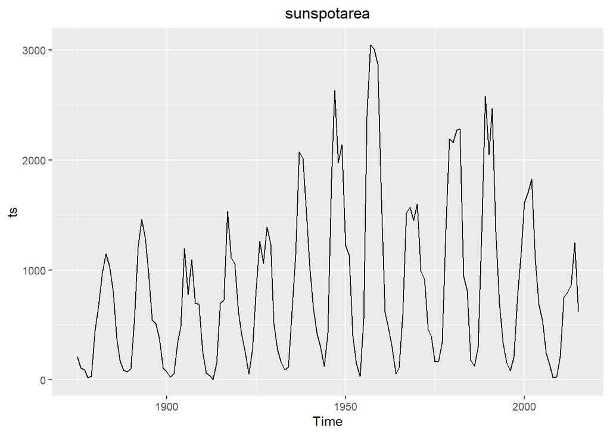

```
## Error in ggseasonplot(ts) : Data are not seasonal
## Error in ggseasonplot(ts, polar = TRUE) : Data are not seasonal
## Error in ggsubseriesplot(ts) : Data are not seasonal
```

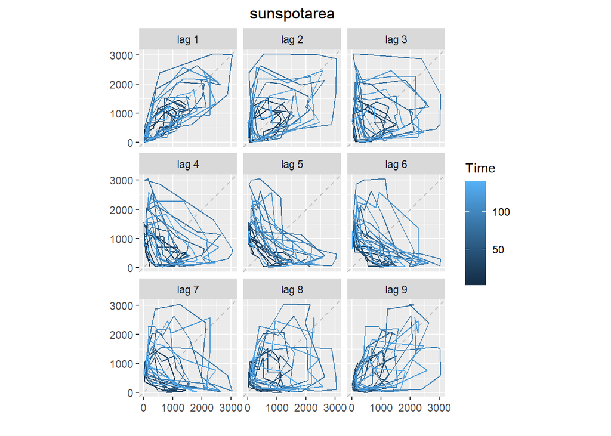

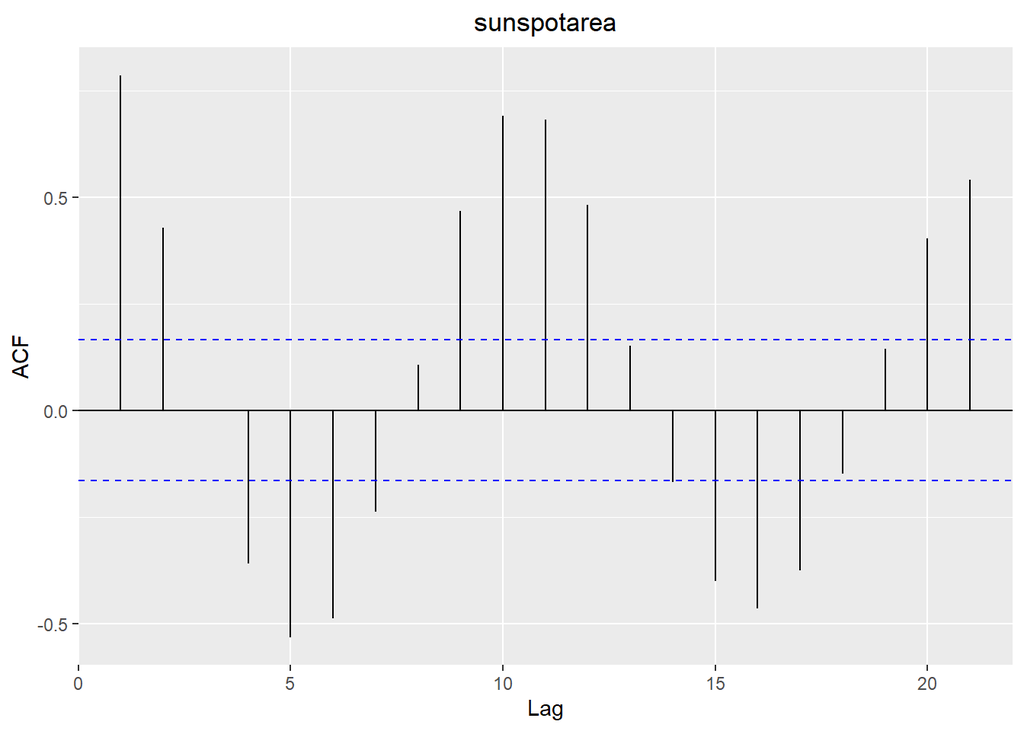

```r
plots_t_ser(sunspotarea, 'sunspotarea')
```

The error messages from the “seasonal” plots immediately show us that the data is not seasonal - there is no surprise her as the data is recorded yearly, but is about the sun. One would not expect data about the sun’s surface to be influenced by the location of the Earth (at least not perceptibly). There does, however, appear to be a cyclicity to the data, with the lag plot indicating that the period of this cycle is around 10 or 11 years, with the area of the spots peaking approximately every 10 years and dipping halfway between the peaks. A little research suggests that there is in fact evidence for a [Sunspot Cycle every 11 years!](https://scied.ucar.edu/sunspot-cycle).

The overall trend is hard to pinpoint with the data we have available - the magnitude of the peaks seems to increase from 1875 to 1957, after which the magnitudes seem to decrease. This may be part of a larger trend in terms of the magnitudes fo the sunspots, but we would need more data to confirm if this is cyclical or some sort of random increase caused by external factors.

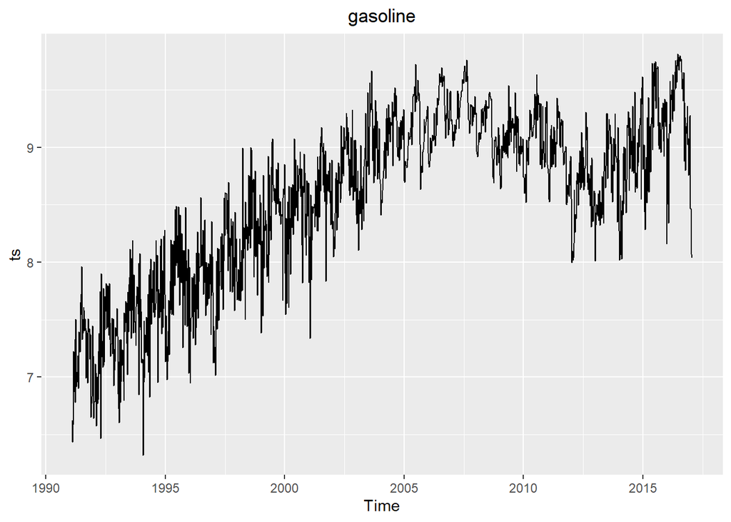

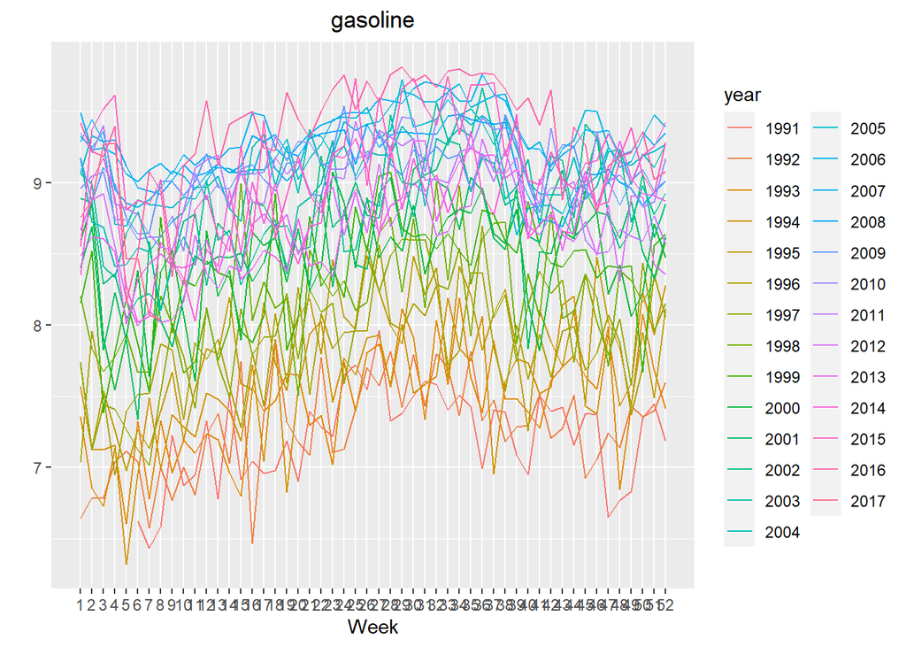

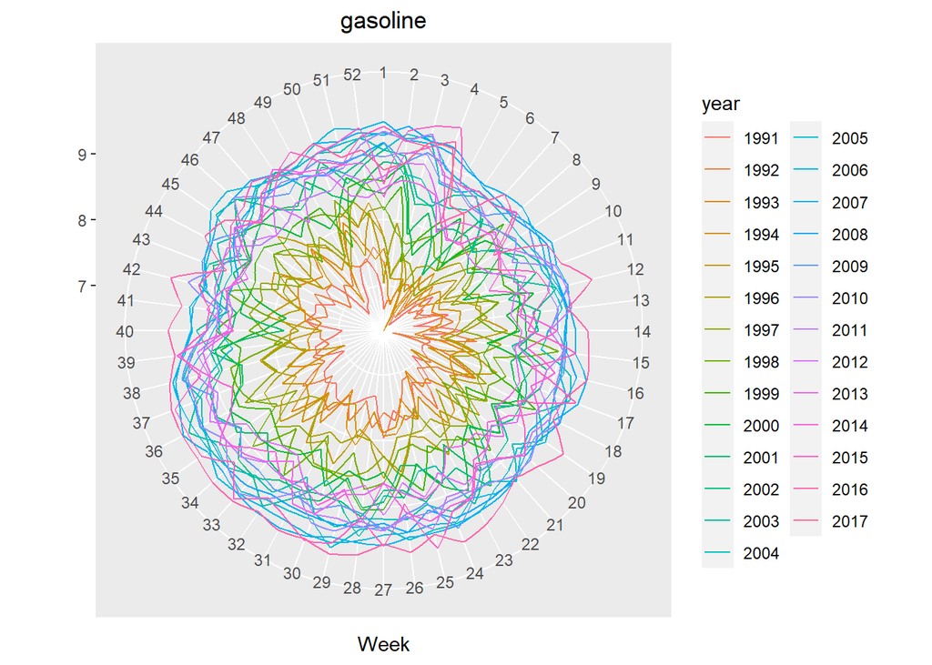

```
## Error in ggsubseriesplot(ts) :
##   Each season requires at least 2 observations. This may be caused from specifying a time-series with non-integer frequency.
```

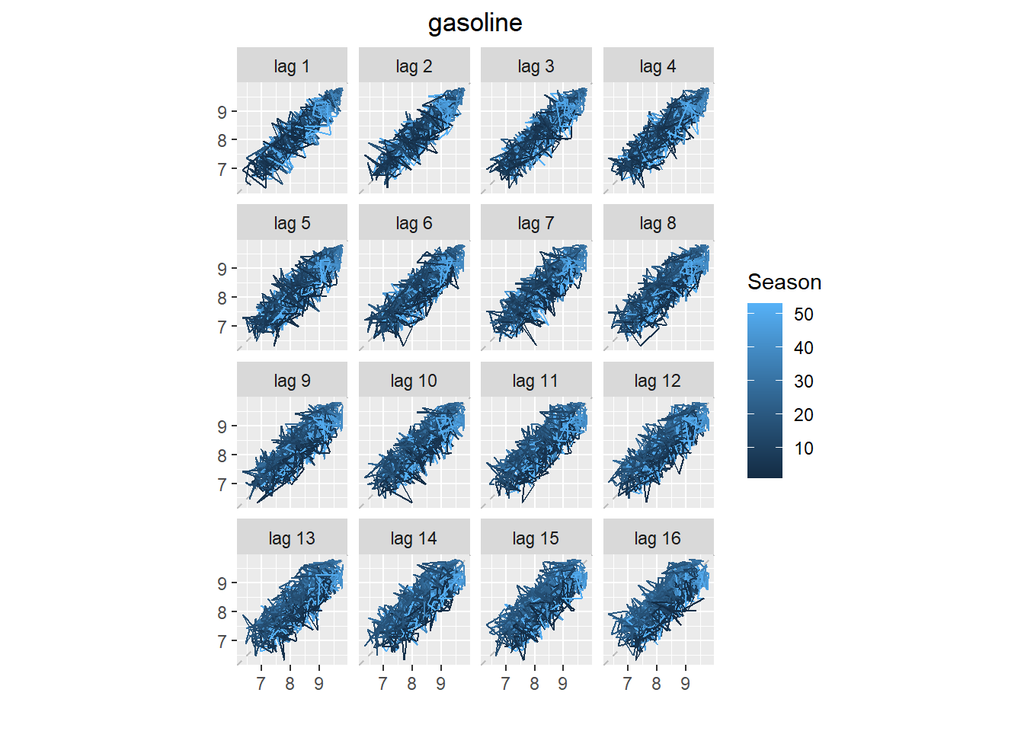

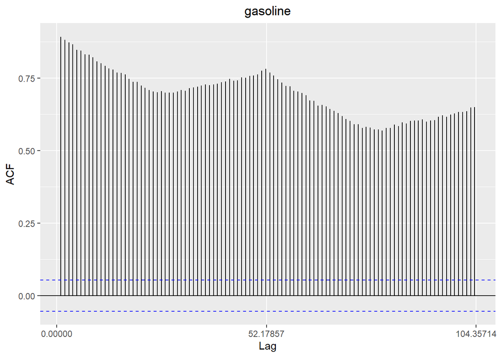

```r
plots_t_ser(gasoline, 'gasoline')
```

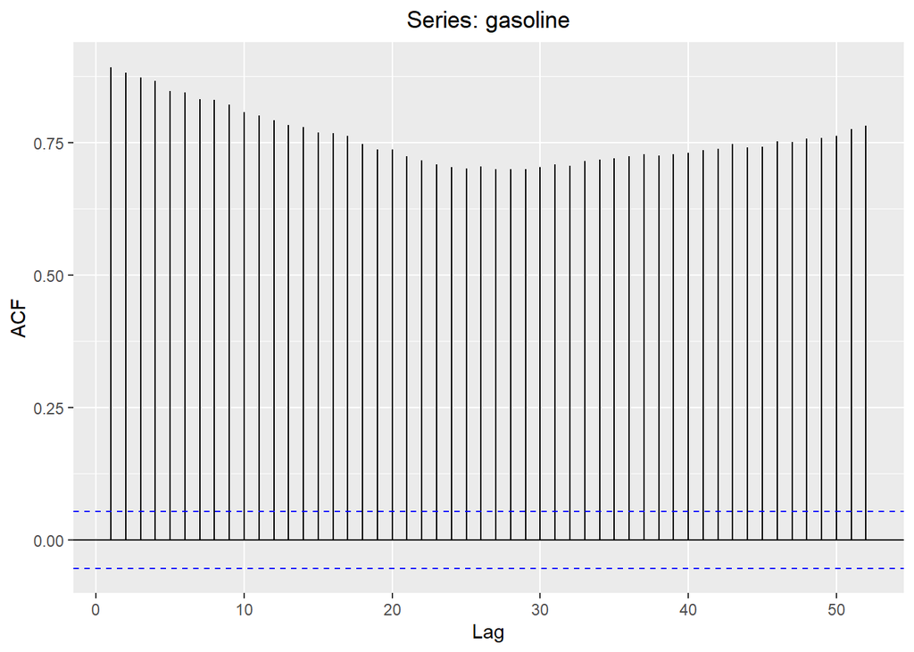

```r
ggAcf(gasoline, lag = 52) +
    theme(plot.title = element_text(hjust = 0.5))
```

The gasoline timeseries shows an increase from 1991 to 2005, with the data leveling off after that. There appears to be little seasonality to the data, though weeks 20-40 do tend to have higher units supplied. As with the Australian Brick data, there is a positive correlation evident throughout the lag graphs, but the latter data does not show as much of this as the earlier data, suggesting that while the overall trend may be positive, more recently this may be leveling off or falling into a cyclical pattern, the confirmation of which would require additional information would be required